# Lung cancer patients

### Gain ratio:

```r
C45Fit <- J48(myFormula, data = train_data)

## Display the confusion matrix for the training set.
table(predict(C45Fit), train_data$Level)
```

```
         Low Medium
  Low     67      0
  Medium   0     10
```

```r
## Display the C4.5 decision tree model details.
print(C45Fit)
```

```
J48 pruned tree
------------------

Alcohol.use <= 2: Low (67.0)
Alcohol.use > 2: Medium (10.0)

Number of Leaves  :     2

Size of the tree :  3
```

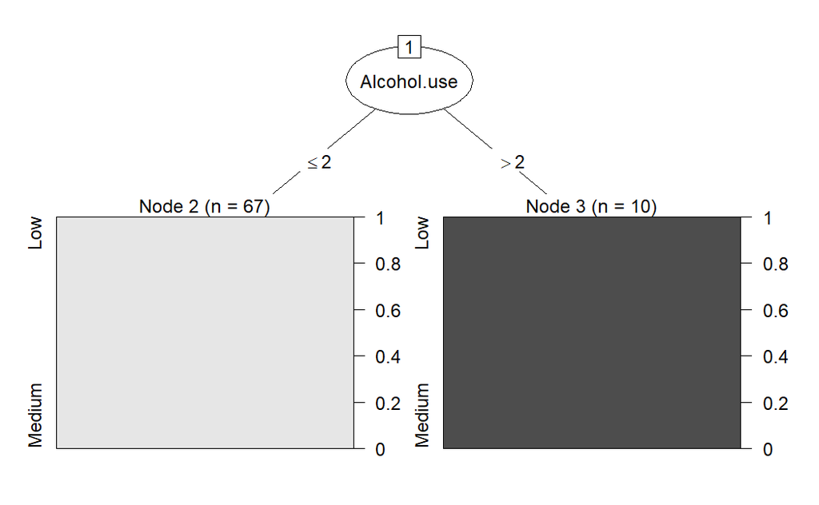

```r
## Plot the C4.5 decision tree model.
plot(C45Fit)
```

As seen in graph the splitting attribute is “Alcohol use”, If the value of “Alcohol use” is *less than or equal to 2*, the prediction is **“Low”** and there are 67 instances in this group. If the value of “Alcohol use” is *greater than 2*, the prediction is **“Medium”** and there are 10 instances in this group. The tree has a size of 3, which includes the root node and two leaves.

```r
## Predict on the testing set using the C4.5 decision tree model.
testPred <- predict(C45Fit, newdata = test_data)

## Evaluate model performance using confusionMatrix for gain ratio.
results <- confusionMatrix(testPred, test_data$Level, positive = "Low")
print(results)
```

```
Confusion Matrix and Statistics

          Reference
Prediction Low Medium
    Low     14      0
    Medium   0      0

               Accuracy : 1
                 95% CI : (0.7684, 1)
    No Information Rate : 1
    P-Value [Acc > NIR] : 1

                  Kappa : NaN

 Mcnemar's Test P-Value : NA

            Sensitivity :  1
            Specificity : NA
         Pos Pred Value : NA
         Neg Pred Value : NA
             Prevalence :  1
         Detection Rate :  1
   Detection Prevalence :  1
      Balanced Accuracy : NA

       'Positive' Class : Low
```

### Gini index:

```r
fit.tree <- rpart(myFormula, data = train_data, method = "class", cp = 0.008)

## Display the Gini decision tree model details.
print(fit.tree)
```

```
n= 77

node), split, n, loss, yval, (yprob)
      * denotes terminal node

1) root 77 10 Low (0.8701299 0.1298701)
  2) Alcohol.use< 3.5 67  0 Low (1.0000000 0.0000000) *
  3) Alcohol.use>=3.5 10  0 Medium (0.0000000 1.0000000) *
```

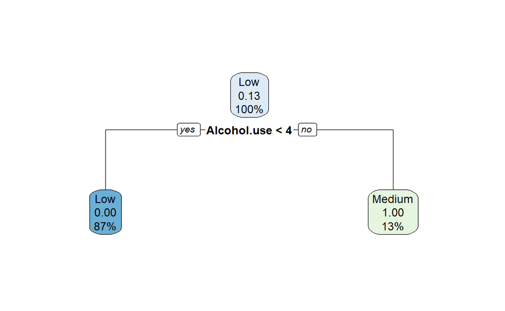

```r
## Plot the Gini decision tree model.
rpart.plot(fit.tree)
```

As seen in the graph the splitting attribute is “Alcohol use”. If “Alcohol use” is less than 4 , the prediction is **“Low”**. If “Alcohol use” is greater or equal to 4, the prediction is **“Medium”**.

```r
## Predict on the testing set using the Gini decision tree model.
testPred <- predict(fit.tree, newdata = test_data, type = "class")

## Evaluate model performance using confusionMatrix for Gini index.
results <- confusionMatrix(testPred, test_data$Level, positive = "Low")
print(results)
```

```
Confusion Matrix and Statistics

          Reference
Prediction Low Medium
    Low     14      0
    Medium   0      0

               Accuracy : 1
                 95% CI : (0.7684, 1)
    No Information Rate : 1
    P-Value [Acc > NIR] : 1

                  Kappa : NaN

 Mcnemar's Test P-Value : NA

            Sensitivity :  1
            Specificity : NA
         Pos Pred Value : NA
         Neg Pred Value : NA
             Prevalence :  1
         Detection Rate :  1
   Detection Prevalence :  1
      Balanced Accuracy : NA

       'Positive' Class : Low
```